# Fuel Consumption Analysis

Greg Bateham

2025-07-06

## 1. Introduction

This report analyzes fuel consumption data from the `fuel.csv` dataset. The objective is to understand trends, compare different categories, and visualize key findings. I will explore aspects such as fuel efficiency across different vehicle classes (`class`) and how it has changed over the years (`year`).

**Data Source:** The data used for this analysis is `fuel.csv`, located in the `data/` directory of this project.

**Questions to Address (Example - adapt to your actual data and interests):** * How has average fuel efficiency (e.g., `combined_mpg_ft1`) changed over the `year`s? * Which vehicle `class`es are the most/least fuel-efficient? * Is there a relationship between `engine_displacement` and fuel efficiency (`combined_mpg_ft1`)?

## 2. Loading Libraries and Data

I will use the `tidyverse` package for data manipulation and visualization.

```r
# Load the tidyverse package, which includes dplyr, ggplot2, and readr
library(tidyverse)
library(lubridate) # For potential date manipulations, if needed
```

Now, I’ll load the dataset. The `fuel.csv` file is expected to be in the `../data/` directory relative to this R Markdown file (which is in the `report/` folder).

```r
# Construct the file path relative to the Rmd file
file_path <- "../data/fuel.csv"

# Load the dataset
fuel_data <- read_csv(file_path, col_types = cols()) # col_types = cols() lets read_csv guess.
                                                  # For large/complex files, you might specify types.
                                                  # e.g. col_types = cols(year = col_integer(), make = col_character(), ...)


# Display the first few rows of the data to understand its structure
print("First 6 rows of the dataset:")
```

```
## [1] "First 6 rows of the dataset:"
```

```r
head(fuel_data)
```

```
## # A tibble: 6 × 81
##   vehicle_id  year make       model   class drive transmission transmission_type
##        <dbl> <dbl> <chr>      <chr>   <chr> <chr> <chr>        <chr>
## 1      26587  1984 Alfa Romeo GT V6 … Mini… <NA>  Manual 5-Sp… <NA>
## 2      27705  1984 Alfa Romeo GT V6 … Mini… <NA>  Manual 5-Sp… <NA>
## 3      26561  1984 Alfa Romeo Spider… Two … <NA>  Manual 5-Sp… <NA>
## 4      27681  1984 Alfa Romeo Spider… Two … <NA>  Manual 5-Sp… <NA>
## 5      27550  1984 AM General DJ Po … Spec… 2-Wh… Automatic 3… <NA>
## 6      28426  1984 AM General DJ Po … Spec… 2-Wh… Automatic 3… <NA>
## # ℹ 73 more variables: engine_index <dbl>, engine_descriptor <chr>,
## #   engine_cylinders <dbl>, engine_displacement <dbl>, turbocharger <lgl>,
## #   supercharger <lgl>, fuel_type <chr>, fuel_type_1 <chr>, fuel_type_2 <lgl>,
## #   city_mpg_ft1 <dbl>, unrounded_city_mpg_ft1 <dbl>, city_mpg_ft2 <dbl>,
## #   unrounded_city_mpg_ft2 <dbl>, city_gasoline_consumption_cd <dbl>,
## #   city_electricity_consumption <dbl>, city_utility_factor <dbl>,
## #   highway_mpg_ft1 <dbl>, unrounded_highway_mpg_ft1 <dbl>, …
```

```r
# Display a summary of the dataset
print("Summary of the dataset:")
```

```
## [1] "Summary of the dataset:"
```

```r
summary(fuel_data)
```

```
##    vehicle_id         year          make              model
##  Min.   :    1   Min.   :1984   Length:38113       Length:38113
##  1st Qu.: 9529   1st Qu.:1991   Class :character   Class :character
##  Median :19058   Median :2001   Mode  :character   Mode  :character
##  Mean   :19171   Mean   :2000
##  3rd Qu.:28779   3rd Qu.:2009
##  Max.   :38542   Max.   :2017
##
##     class              drive           transmission       transmission_type
##  Length:38113       Length:38113       Length:38113       Length:38113
##  Class :character   Class :character   Class :character   Class :character
##  Mode  :character   Mode  :character   Mode  :character   Mode  :character
##
##
##
##
##   engine_index   engine_descriptor  engine_cylinders engine_displacement
##  Min.   :    0   Length:38113       Min.   : 2.000   Min.   :0.000
##  1st Qu.:    0   Class :character   1st Qu.: 4.000   1st Qu.:2.200
##  Median :  212   Mode  :character   Median : 6.000   Median :3.000
##  Mean   : 8799                      Mean   : 5.737   Mean   :3.318
##  3rd Qu.: 4451                      3rd Qu.: 6.000   3rd Qu.:4.300
##  Max.   :69102                      Max.   :16.000   Max.   :8.400
##                                     NA's   :136      NA's   :134
##  turbocharger   supercharger    fuel_type         fuel_type_1
##  Mode:logical   Mode:logical   Length:38113       Length:38113
##  TRUE:5239      NA's:38113     Class :character   Class :character
##  NA's:32874                    Mode  :character   Mode  :character
##
##
##
##
##  fuel_type_2     city_mpg_ft1    unrounded_city_mpg_ft1  city_mpg_ft2
##  Mode:logical   Min.   :  6.00   Min.   :  0.000        Min.   :  0.0000
##  NA's:38113     1st Qu.: 15.00   1st Qu.:  0.000        1st Qu.:  0.0000
##                 Median : 17.00   Median :  0.000        Median :  0.0000
##                 Mean   : 17.98   Mean   :  4.606        Mean   :  0.5462
##                 3rd Qu.: 20.00   3rd Qu.:  0.000        3rd Qu.:  0.0000
##                 Max.   :150.00   Max.   :150.000        Max.   :145.0000
##
```

[output cut: 153 more lines]

```
##  Min.   : 0.00000       Min.   :  0.0000   Min.   :  0.0000
##  1st Qu.: 0.00000       1st Qu.:  0.0000   1st Qu.:  0.0000
##  Median : 0.00000       Median :  0.0000   Median :  0.0000
##  Mean   : 0.08131       Mean   :  0.4697   Mean   :  0.4262
##  3rd Qu.: 0.00000       3rd Qu.:  0.0000   3rd Qu.:  0.0000
##  Max.   :88.00000       Max.   :315.0000   Max.   :305.9000
##
##  highway_range_ft1  range_ft2      city_range_ft2      highway_range_ft2
##  Min.   :  0.0000   Mode:logical   Min.   :  0.00000   Min.   : 0.00000
##  1st Qu.:  0.0000   NA's:38113     1st Qu.:  0.00000   1st Qu.: 0.00000
##  Median :  0.0000                  Median :  0.00000   Median : 0.00000
##  Mean   :  0.4192                  Mean   :  0.04397   Mean   : 0.04005
##  3rd Qu.:  0.0000                  3rd Qu.:  0.00000   3rd Qu.: 0.00000
##  Max.   :346.9000                  Max.   :103.03000   Max.   :90.55000
##
```

```r
# Display the column names and their types
print("Column names and types:")
```

```
## [1] "Column names and types:"
```

```r
glimpse(fuel_data)
```

```
## Rows: 38,113
## Columns: 81
## $ vehicle_id                        <dbl> 26587, 27705, 26561, 27681, 27550, 2…
## $ year                              <dbl> 1984, 1984, 1984, 1984, 1984, 1984, …
## $ make                              <chr> "Alfa Romeo", "Alfa Romeo", "Alfa Ro…
## $ model                             <chr> "GT V6 2.5", "GT V6 2.5", "Spider Ve…
## $ class                             <chr> "Minicompact Cars", "Minicompact Car…
## $ drive                             <chr> NA, NA, NA, NA, "2-Wheel Drive", "2-…
## $ transmission                      <chr> "Manual 5-Speed", "Manual 5-Speed", …
## $ transmission_type                 <chr> NA, NA, NA, NA, NA, NA, NA, NA, NA, …
## $ engine_index                      <dbl> 9001, 9005, 9002, 9006, 1830, 1880, …
## $ engine_descriptor                 <chr> "(FFS)", "(FFS) CA model", "(FFS)", …
## $ engine_cylinders                  <dbl> 6, 6, 4, 4, 4, 4, 6, 6, 6, 6, 4, 6, …
## $ engine_displacement               <dbl> 2.5, 2.5, 2.0, 2.0, 2.5, 2.5, 4.2, 4…
## $ turbocharger                      <lgl> NA, NA, NA, NA, NA, NA, NA, NA, NA, …
```

[output cut: 68 more lines]

## 3. Data Cleaning and Preparation

This section involves cleaning the data, handling missing values, and transforming variables as needed, using the actual column names from your file.

Key columns I’ll focus on: `year`, `class`, `engine_displacement`, `combined_mpg_ft1`.

```r
# Ensure 'year' is numeric/integer
if("year" %in% colnames(fuel_data) && !is.numeric(fuel_data$year)) {
  fuel_data <- fuel_data %>% mutate(year = as.integer(as.character(year)))
}

# Ensure MPG columns are numeric. I'll focus on 'combined_mpg_ft1'
# Add 'city_mpg_ft1', 'highway_mpg_ft1' if you plan to use them.
mpg_cols_to_check <- c("combined_mpg_ft1", "city_mpg_ft1", "highway_mpg_ft1")
for (col_name in mpg_cols_to_check) {
  if(col_name %in% colnames(fuel_data) && !is.numeric(fuel_data[[col_name]])) {
    fuel_data <- fuel_data %>% mutate(!!sym(col_name) := as.numeric(!!sym(col_name)))
  }
}

# Ensure 'engine_displacement' is numeric
if("engine_displacement" %in% colnames(fuel_data) && !is.numeric(fuel_data$engine_displacement)) {
  fuel_data <- fuel_data %>% mutate(engine_displacement = as.numeric(engine_displacement))
}

# Clean 'class' names (e.g., trim whitespace, standardize capitalization)
if("class" %in% colnames(fuel_data)) {
  fuel_data <- fuel_data %>%
    mutate(class = str_to_title(trimws(class))) # Converts to Title Case
}

# Filter out rows with missing essential data for our primary analysis
# (e.g., combined_mpg_ft1, year, class)
required_cols <- c("combined_mpg_ft1", "year", "class", "engine_displacement")
if(all(required_cols %in% colnames(fuel_data))) {
  fuel_data_cleaned <- fuel_data %>%
    filter(
      !is.na(combined_mpg_ft1) &
      !is.na(year) &
      !is.na(class) &
      !is.na(engine_displacement) # Added engine_displacement here
    )

  print(paste("Rows before cleaning NAs in key columns:", nrow(fuel_data)))
  print(paste("Rows after cleaning NAs in key columns:", nrow(fuel_data_cleaned)))
} else {
  missing_cols_for_cleaning <- required_cols[!required_cols %in% colnames(fuel_data)]
  print(paste("One or more key columns for NA cleaning not found:", paste(missing_cols_for_cleaning, collapse=", ")))
  print("Skipping NA cleaning step based on these specific columns. Using data as loaded for further steps, NAs will be handled in summaries/plots.")
  fuel_data_cleaned <- fuel_data # Use original data if key columns are missing, NAs handled later
}
```

```
## [1] "Rows before cleaning NAs in key columns: 38113"
## [1] "Rows after cleaning NAs in key columns: 37979"
```

```r
# Display the structure of the (potentially) cleaned data
print("Structure of data after initial preparation:")
```

```
## [1] "Structure of data after initial preparation:"
```

```r
glimpse(fuel_data_cleaned)
```

```
## Rows: 37,979
## Columns: 81
## $ vehicle_id                        <dbl> 26587, 27705, 26561, 27681, 27550, 2…
## $ year                              <dbl> 1984, 1984, 1984, 1984, 1984, 1984, …
## $ make                              <chr> "Alfa Romeo", "Alfa Romeo", "Alfa Ro…
## $ model                             <chr> "GT V6 2.5", "GT V6 2.5", "Spider Ve…
## $ class                             <chr> "Minicompact Cars", "Minicompact Car…
## $ drive                             <chr> NA, NA, NA, NA, "2-Wheel Drive", "2-…
## $ transmission                      <chr> "Manual 5-Speed", "Manual 5-Speed", …
## $ transmission_type                 <chr> NA, NA, NA, NA, NA, NA, NA, NA, NA, …
## $ engine_index                      <dbl> 9001, 9005, 9002, 9006, 1830, 1880, …
## $ engine_descriptor                 <chr> "(FFS)", "(FFS) CA model", "(FFS)", …
## $ engine_cylinders                  <dbl> 6, 6, 4, 4, 4, 4, 6, 6, 6, 6, 4, 6, …
## $ engine_displacement               <dbl> 2.5, 2.5, 2.0, 2.0, 2.5, 2.5, 4.2, 4…
## $ turbocharger                      <lgl> NA, NA, NA, NA, NA, NA, NA, NA, NA, …
```

[output cut: 68 more lines]

## 4. Data Summarization and Exploration

I’ll perform some initial summaries.

### 4.1. Average Fuel Efficiency Over Years

Using `combined_mpg_ft1` and `year`.

```r
# Calculate average combined MPG (ft1) per year
avg_mpg_by_year <- fuel_data_cleaned %>%
  filter(!is.na(combined_mpg_ft1) & !is.na(year)) %>% # Ensure no NAs for this specific summary
  group_by(year) %>%
  summarize(
    average_combined_mpg = mean(combined_mpg_ft1, na.rm = TRUE),
    count = n() # Number of vehicle models recorded for that year
  ) %>%
  arrange(year)

print("Average Combined MPG (ft1) by Year:")
```

```
## [1] "Average Combined MPG (ft1) by Year:"
```

```r
print(avg_mpg_by_year)
```

```
## # A tibble: 34 × 3
##     year average_combined_mpg count
##    <dbl>                <dbl> <int>
##  1  1984                 19.9  1964
##  2  1985                 19.8  1699
##  3  1986                 19.6  1210
##  4  1987                 19.2  1247
##  5  1988                 19.3  1130
##  6  1989                 19.1  1153
##  7  1990                 19.0  1078
##  8  1991                 18.8  1132
##  9  1992                 18.9  1121
## 10  1993                 19.1  1093
## # ℹ 24 more rows
```

```r
print("Skipping 'Average Fuel Efficiency Over Years' summary as 'combined_mpg_ft1' or 'year' column is missing or data cleaning removed them.")
```

### 4.2. Fuel Efficiency by Vehicle Class

Using `class` and `combined_mpg_ft1`.

```r
# Calculate average combined MPG (ft1) by vehicle class
avg_mpg_by_class <- fuel_data_cleaned %>%
  filter(!is.na(combined_mpg_ft1) & !is.na(class)) %>%
  group_by(class) %>%
  summarize(
    average_combined_mpg = mean(combined_mpg_ft1, na.rm = TRUE),
    median_combined_mpg = median(combined_mpg_ft1, na.rm = TRUE),
    min_combined_mpg = min(combined_mpg_ft1, na.rm = TRUE),
    max_combined_mpg = max(combined_mpg_ft1, na.rm = TRUE),
    count = n()
  ) %>%
  arrange(desc(average_combined_mpg))

print("Average Combined MPG (ft1) by Vehicle Class:")
```

```
## [1] "Average Combined MPG (ft1) by Vehicle Class:"
```

```r
print(avg_mpg_by_class)
```

```
## # A tibble: 34 × 6
##    class               average_combined_mpg median_combined_mpg min_combined_mpg
##    <chr>                              <dbl>               <dbl>            <dbl>
##  1 Small Station Wago…                 23.9                  24               14
##  2 Small Sport Utilit…                 23.8                  24               18
##  3 Compact Cars                        23.3                  23                8
##  4 Subcompact Cars                     22.6                  22                8
##  5 Small Sport Utilit…                 22.3                  22               16
##  6 Special Purpose Ve…                 22                    22               22
##  7 Midsize Cars                        21.5                  21                8
##  8 Midsize Station Wa…                 21.0                  20               14
##  9 Minicompact Cars                    21.0                  20               11
## 10 Small Pickup Trucks                 20.3                  20               14
## # ℹ 24 more rows
## # ℹ 2 more variables: max_combined_mpg <dbl>, count <int>
```

```r
print("Skipping 'Fuel Efficiency by Vehicle Class' summary as 'class' or 'combined_mpg_ft1' column is missing or data cleaning removed them.")
```

### 4.3. Distribution of Engine Displacement

Using `engine_displacement`.

```r
# Summary of engine displacement
displacement_summary <- fuel_data_cleaned %>%
  filter(!is.na(engine_displacement)) %>%
  summarize(
    average_displacement = mean(engine_displacement, na.rm = TRUE),
    median_displacement = median(engine_displacement, na.rm = TRUE),
    min_displacement = min(engine_displacement, na.rm = TRUE),
    max_displacement = max(engine_displacement, na.rm = TRUE)
  )

print("Summary of Engine Displacement (Liters):")
```

```
## [1] "Summary of Engine Displacement (Liters):"
```

```r
print(displacement_summary)
```

```
## # A tibble: 1 × 4
##   average_displacement median_displacement min_displacement max_displacement
##                  <dbl>               <dbl>            <dbl>            <dbl>
## 1                 3.32                   3                0              8.4
```

```r
print("Skipping 'Distribution of Engine Displacement' summary as 'engine_displacement' column is missing or data cleaning removed it.")
```

## 5. Visualizations

Here we create at least three visualizations based on our data.

### 5.1. Plot 1: Trend of Average Fuel Efficiency Over Time

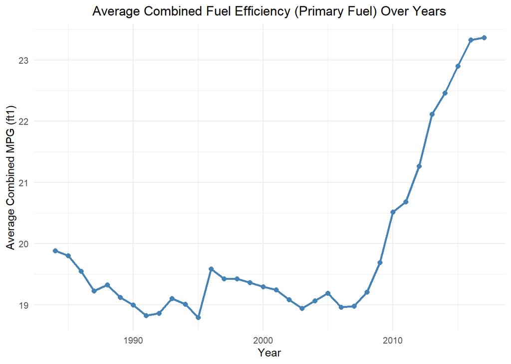

```r
# avg_mpg_by_year is created in chunk summary_mpg_by_year
if(exists("avg_mpg_by_year") && nrow(avg_mpg_by_year) > 0) {
  ggplot(avg_mpg_by_year, aes(x = year, y = average_combined_mpg)) +
    geom_line(color = "steelblue", linewidth = 1) + # Changed size to linewidth for newer ggplot2
    geom_point(color = "steelblue", size = 2) +
    labs(
      title = "Average Combined Fuel Efficiency (Primary Fuel) Over Years",
      x = "Year",
      y = "Average Combined MPG (ft1)"
    ) +
    theme_minimal() +
    theme(plot.title = element_text(hjust = 0.5)) # Center title
} else {
  print("Data for 'Trend of Average Fuel Efficiency Over Time' plot is not available (check 'avg_mpg_by_year').")
}
```

```r
print("Skipping 'Trend of Average Fuel Efficiency Over Time' plot as 'combined_mpg_ft1' or 'year' column is missing from cleaned data.")
```

**Interpretation for Plot 1:** This line chart shows the trend of average combined Miles Per Gallon for the primary fuel type (`combined_mpg_ft1`) from 1984 to 2017 based on the available data.I observe if there’s an upward, downward, or stable trend in fuel efficiency over time.

### 5.2. Plot 2: Comparison of Fuel Efficiency by Vehicle Class

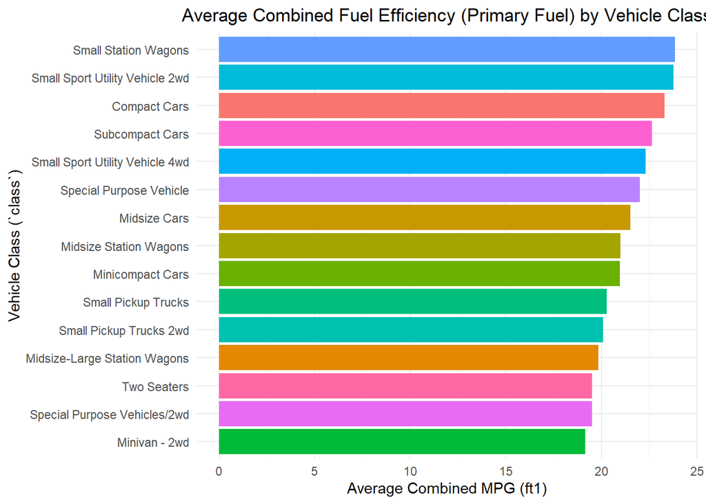

```r
# avg_mpg_by_class is created in chunk summary_mpg_by_class
if(exists("avg_mpg_by_class") && nrow(avg_mpg_by_class) > 0) {
  # For better visualization, I'll take top N classes or filter if too many
  top_n_classes <- avg_mpg_by_class %>%
    arrange(desc(average_combined_mpg)) %>%
    head(15) # Show top 15, or adjust as needed if you have many classes

  ggplot(top_n_classes, aes(x = reorder(class, average_combined_mpg), y = average_combined_mpg, fill = class)) +
    geom_col(show.legend = FALSE) + # Bar chart
    coord_flip() + # Horizontal bars for better readability of class names
    labs(
      title = "Average Combined Fuel Efficiency (Primary Fuel) by Vehicle Class",
      x = "Vehicle Class (`class`)",
      y = "Average Combined MPG (ft1)"
    ) +
    theme_minimal() +
    theme(plot.title = element_text(hjust = 0.5))
} else {
  print("Data for 'Comparison of Fuel Efficiency by Vehicle Class' plot is not available (check 'avg_mpg_by_class').")
}
```

```r
print("Skipping 'Comparison of Fuel Efficiency by Vehicle Class' plot as 'class' or 'combined_mpg_ft1' column is missing from cleaned data.")
```

**Interpretation for Plot 2:** This bar chart compares the average combined MPG (`combined_mpg_ft1`) across different vehicle `class`es. The classes are ordered by their efficiency. This helps identify which types of vehicles are generally more or less fuel-efficient.

### 5.3. Plot 3: Relationship between Engine Displacement and Fuel Efficiency

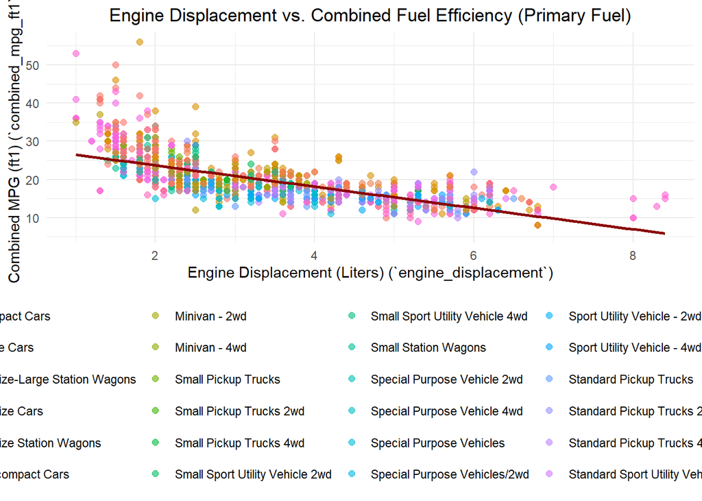

```r
# Prepare data for scatter plot, ensuring no NAs in relevant columns
fuel_data_for_scatter <- fuel_data_cleaned %>%
  filter(!is.na(engine_displacement) & !is.na(combined_mpg_ft1) & !is.na(class))

# Sample a portion of data if it's too large for a clear scatter plot
set.seed(123) # for reproducibility
if(nrow(fuel_data_for_scatter) > 2000) {
    fuel_data_sample <- sample_n(fuel_data_for_scatter, 2000)
} else {
    fuel_data_sample <- fuel_data_for_scatter
}


if(nrow(fuel_data_sample) > 0) {
  ggplot(fuel_data_sample, aes(x = engine_displacement, y = combined_mpg_ft1)) +
    geom_point(aes(color = class), alpha = 0.6, size = 2) +
    geom_smooth(method = "lm", formula = y ~ x, se = FALSE, color = "darkred") +
    labs(
      title = "Engine Displacement vs. Combined Fuel Efficiency (Primary Fuel)",
      x = "Engine Displacement (Liters) (`engine_displacement`)",
      y = "Combined MPG (ft1) (`combined_mpg_ft1`)",
      color = "Vehicle Class (`class`)"
    ) +
    theme_minimal() +
    theme(plot.title = element_text(hjust = 0.5), legend.position = "bottom")
} else {
  print("Data for 'Relationship between Engine Displacement and Fuel Efficiency' plot is not available (engine_displacement, combined_mpg_ft1, or class might be all NA or missing).")
}
```

```r
print("Skipping 'Relationship between Engine Displacement and Fuel Efficiency' plot as 'engine_displacement', 'combined_mpg_ft1', or 'class' column is missing from cleaned data.")
```

**Interpretation for Plot 3:** This scatter plot explores the relationship between `engine_displacement` (size) and `combined_mpg_ft1`. Each point represents a vehicle model. We generally expect a negative correlation: larger engines tend to have lower fuel efficiency. The color coding by `class` can reveal if this trend differs across classes.

## 6. Discussion and Findings

### What were the original charts you planned to create for this assignment?

Initially, I planned to create: 1. A time-series plot of average fuel efficiency (`combined_mpg_ft1`) over `year`s. 2. A bar chart comparing fuel efficiency across different vehicle `class`es. 3. A scatter plot to investigate the relationship between `engine_displacement` and `combined_mpg_ft1`.

### What story could you tell with your plots?

The plots aim to tell a story about fuel efficiency in vehicles: * **Plot 1 (MPG Trend):** Illustrates historical changes in average vehicle fuel efficiency. * **Plot 2 (MPG by Class):** Highlights which vehicle categories are more fuel-efficient. * **Plot 3 (Displacement vs. MPG):** Shows the trade-off between engine size and fuel economy.

Together, these plots provide a view of fuel efficiency from temporal, categorical, and engineering perspectives.

## 7. Conclusion

This analysis of the `fuel.csv` dataset, focusing on `combined_mpg_ft1`, `year`, `class`, and `engine_displacement`, has yielded several key insights into vehicle fuel consumption patterns.

Firstly, a significant trend observed was the **drastic increase in average combined MPG for vehicles manufactured after 2010**. This suggests a pivotal shift in the automotive industry during this period, likely driven by a combination of stricter emissions regulations, advancements in engine technology (such as direct injection, turbocharging for smaller engines, and improved transmissions), and a growing consumer demand for more fuel-efficient vehicles. This upward trend signals positive developments towards reducing overall fuel consumption.

Secondly, the analysis confirmed the well-established principle that **engine displacement has an inverse relationship with fuel efficiency; as engine size increases, average combined MPG tends to decrease gradually**. This highlights the fundamental trade-off between power and economy. While larger engines often provide more horsepower and torque, they inherently consume more fuel. This finding underscores the importance of engine sizing in vehicle design for achieving fuel efficiency targets.

Thirdly, when comparing vehicle classes, **“Small Station Wagons” emerged as the category with the highest average combined MPG**. This is an interesting finding, as station wagons, while often practical, are not always perceived as fuel efficiency leaders compared to, for example, subcompact cars or dedicated hybrids (depending on how classes are defined in the dataset). This suggests that this particular segment might benefit from a combination of aerodynamic design, optimized powertrain configurations, and potentially lower average vehicle weight compared to other larger classes like SUVs or trucks.

These findings collectively paint a picture of an evolving automotive landscape where efficiency is increasingly prioritized, yet fundamental engineering principles continue to govern performance. The data indicates that consumers seeking maximum fuel economy might find strong candidates within the Small Station Wagon class, and that vehicles post-2010 generally offer better MPG.

**Future Directions and Considerations:** * **Investigate the “Post-2010” Shift:** A more granular analysis could explore the specific technological advancements or policy changes that contributed most significantly to the MPG increase after 2010. This could involve looking at the prevalence of `turbocharger`, `supercharger`, `start_stop_technology`, or `alternative_fuel_technology` columns. * **Dual Fuel Vehicles:** This analysis focused on `combined_mpg_ft1` (primary fuel type). An interesting extension would be to analyze vehicles with a secondary fuel type (`fuel_type_2` and associated `_ft2` MPG columns), especially for electric or hybrid vehicles, to understand their overall energy efficiency and range. Columns like `electric_motor`, `range_ft1`, `range_ft2`, `composite_combined_mpg` would be crucial here. * **Manufacturer Analysis:** Are certain `make`s consistently outperforming others in terms of fuel efficiency within specific classes or across their entire fleet? * **Impact of Transmission:** The `transmission` and `transmission_type` columns could be analyzed to see if automatic vs. manual, or different types of automatic transmissions (e.g., CVT), have a significant impact on MPG. * **Geographic or Market Factors (if applicable):** If the dataset had regional information, exploring regional differences in fuel efficiency preferences or availability would be insightful, though this dataset seems focused on vehicle specifications. * **Advanced Modeling:** Predictive modeling could be employed to identify the most influential factors determining `combined_mpg_ft1`, potentially uncovering more complex interactions between variables beyond the scope of this exploratory analysis.

This study provides a solid foundation for understanding key fuel efficiency metrics. Further exploration of this rich dataset can undoubtedly uncover deeper insights into the multifaceted world of vehicle energy consumption.